# Part I - (Prosper Loan Data)

## Introduction

Loan Data from Prosper: This data set contains 113,937 loans with 81 variables on each loan, including loan amount, borrower rate (or interest rate), current loan status, borrower income, and many others. See this data dictionary to understand the dataset's variables.

## Preliminary Wrangling

```python
# import all packages and set plots to be embedded inline
import numpy as np
import pandas as pd
import matplotlib.pyplot as plt
import seaborn as sb

%matplotlib inline
```

> Load in your dataset and describe its properties through the questions below. Try and motivate your exploration goals through this section.

```python
df= pd.read_csv('prosperLoanData.csv')
df.head(4)
```

|  | ListingKey | ListingNumber | ListingCreationDate | CreditGrade | Term | LoanStatus | ClosedDate | BorrowerAPR | BorrowerRate | LenderYield | ... | LP_ServiceFees | LP_CollectionFees | LP_GrossPrincipalLoss | LP_NetPrincipalLoss | LP_NonPrincipalRecoverypayments | PercentFunded | Recommendations | InvestmentFromFriendsCount | InvestmentFromFriendsAmount | Investors |
| --- | --- | --- | --- | --- | --- | --- | --- | --- | --- | --- | --- | --- | --- | --- | --- | --- | --- | --- | --- | --- | --- |
| 0 | 1021339766868145413AB3B | 193129 | 2007-08-26 19:09:29.263000000 | C | 36 | Completed | 2009-08-14 00:00:00 | 0.16516 | 0.1580 | 0.1380 | ... | -133.18 | 0.0 | 0.0 | 0.0 | 0.0 | 1.0 | 0 | 0 | 0.0 | 258 |
| 1 | 10273602499503308B223C1 | 1209647 | 2014-02-27 08:28:07.900000000 | NaN | 36 | Current | NaN | 0.12016 | 0.0920 | 0.0820 | ... | 0.00 | 0.0 | 0.0 | 0.0 | 0.0 | 1.0 | 0 | 0 | 0.0 | 1 |
| 2 | 0EE9337825851032864889A | 81716 | 2007-01-05 15:00:47.090000000 | HR | 36 | Completed | 2009-12-17 00:00:00 | 0.28269 | 0.2750 | 0.2400 | ... | -24.20 | 0.0 | 0.0 | 0.0 | 0.0 | 1.0 | 0 | 0 | 0.0 | 41 |
| 3 | 0EF5356002482715299901A | 658116 | 2012-10-22 11:02:35.010000000 | NaN | 36 | Current | NaN | 0.12528 | 0.0974 | 0.0874 | ... | -108.01 | 0.0 | 0.0 | 0.0 | 0.0 | 1.0 | 0 | 0 | 0.0 | 158 |

4 rows × 81 columns

```python
pd.set_option('display.max_rows', None)
```

```python
df.info()
```

```
<class 'pandas.core.frame.DataFrame'>
RangeIndex: 113937 entries, 0 to 113936
Data columns (total 81 columns):
 #   Column                               Non-Null Count   Dtype
---  ------                               --------------   -----
 0   ListingKey                           113937 non-null  object
 1   ListingNumber                        113937 non-null  int64
 2   ListingCreationDate                  113937 non-null  object
 3   CreditGrade                          28953 non-null   object
 4   Term                                 113937 non-null  int64
 5   LoanStatus                           113937 non-null  object
 6   ClosedDate                           55089 non-null   object
 7   BorrowerAPR                          113912 non-null  float64
 8   BorrowerRate                         113937 non-null  float64
 9   LenderYield                          113937 non-null  float64
```

[output cut: 73 more lines]

```python
df.isna().sum()
```

```
ListingKey                                  0
ListingNumber                               0
ListingCreationDate                         0
CreditGrade                             84984
Term                                        0
LoanStatus                                  0
ClosedDate                              58848
BorrowerAPR                                25
BorrowerRate                                0
LenderYield                                 0
EstimatedEffectiveYield                 29084
EstimatedLoss                           29084
EstimatedReturn                         29084
ProsperRating (numeric)                 29084
ProsperRating (Alpha)                   29084
ProsperScore                            29084
ListingCategory (numeric)                   0
BorrowerState                            5515
Occupation                               3588
EmploymentStatus                         2255
EmploymentStatusDuration                 7625
IsBorrowerHomeowner                         0
CurrentlyInGroup                            0
GroupKey                               100596
DateCreditPulled                            0
CreditScoreRangeLower                     591
CreditScoreRangeUpper                     591
FirstRecordedCreditLine                   697
CurrentCreditLines                       7604
OpenCreditLines                          7604
TotalCreditLinespast7years                697
OpenRevolvingAccounts                       0
OpenRevolvingMonthlyPayment                 0
InquiriesLast6Months                      697
TotalInquiries                           1159
CurrentDelinquencies                      697
AmountDelinquent                         7622
DelinquenciesLast7Years                   990
PublicRecordsLast10Years                  697
PublicRecordsLast12Months                7604
```

[output cut: 27 more lines]

```
MonthlyLoanPayment                          0
LP_CustomerPayments                         0
LP_CustomerPrincipalPayments                0
LP_InterestandFees                          0
LP_ServiceFees                              0
LP_CollectionFees                           0
LP_GrossPrincipalLoss                       0
LP_NetPrincipalLoss                         0
LP_NonPrincipalRecoverypayments             0
PercentFunded                               0
Recommendations                             0
InvestmentFromFriendsCount                  0
InvestmentFromFriendsAmount                 0
Investors                                   0
dtype: int64
```

### What is the structure of your dataset?

> The ProsperLoan dataset has 113937 entries and 81 columns.

### What is/are the main feature(s) of interest in your dataset?

> Loan status is my main feature, i want to know how loan being fully repaid is dependent on the other features.

### What features in the dataset do you think will help support your investigation into your feature(s) of interest?

> - The variables that will help support my investigation are: Term, Occupation, LoanOriginalAmount, EmploymentStatus, MonthlyLoanPayment, IncomeRange, ProsperScore, BorrowerRate

## Univariate Exploration

> In this section, investigate distributions of individual variables. If you see unusual points or outliers, take a deeper look to clean things up and prepare yourself to look at relationships between variables.

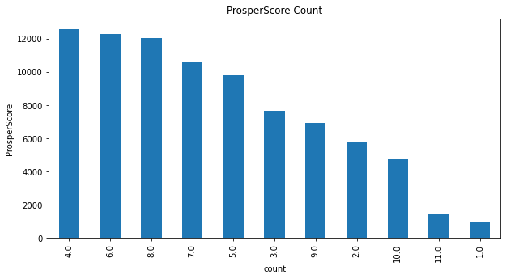

```python
#prosperscore
prosper=  df.ProsperScore.value_counts()
plt.figure(figsize=(10,5))
prosper.plot(kind='bar')
plt.title('ProsperScore Count')
plt.xlabel('count')
plt.ylabel('ProsperScore')
```

Majority of borrowers have a prosper count of 4 followed closed by 6 then 8. The least being 1.

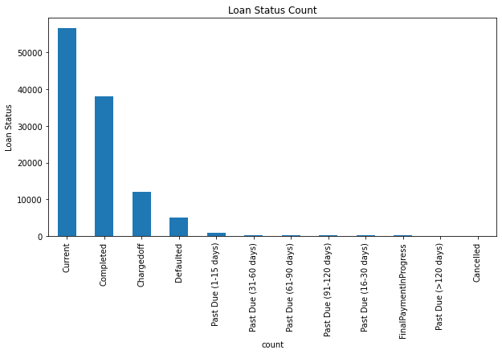

```python
#loan status
status = df.LoanStatus.value_counts()
plt.figure(figsize=(10,5))
status.plot(kind='bar')
plt.title('Loan Status Count')
plt.xlabel('count')
plt.ylabel('Loan Status')
```

Majority of the loan status is current, followed by completed and the least is cancelled.

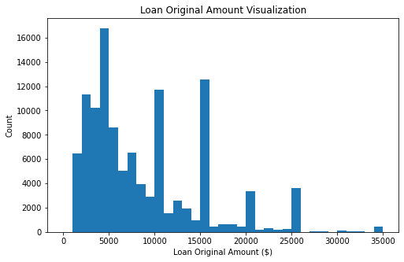

```python
#loan original amount
df.LoanOriginalAmount.value_counts()
binsize = 1000
bins = np.arange(0, df['LoanOriginalAmount'].max()+binsize, binsize)

plt.figure(figsize=[8, 5])
plt.hist(data = df, x = 'LoanOriginalAmount', bins = bins)
plt.xlabel('Loan Original Amount ($)')
plt.ylabel('Count')
plt.title('Loan Original Amount Visualization')
plt.show()
```

There is a tail in the distribution , so let us use log scale to normalize

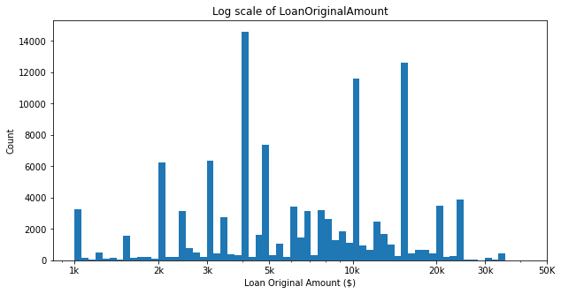

```python
log_binsize = 0.025
bins = 10 ** np.arange(3, np.log10(df['LoanOriginalAmount'].max())+log_binsize, log_binsize)

plt.figure(figsize=[10, 5])
plt.hist(data = df, x = 'LoanOriginalAmount', bins = bins)
plt.xscale('log')
plt.xticks([1e3, 2e3, 3e3, 5e3, 1e4, 2e4, 3e4, 5e4], ['1k', '2k','3k', '5k', '10k', '20k', '30k', '50K'])
plt.xlabel('Loan Original Amount ($)')
plt.ylabel('Count')
plt.title('Log scale of LoanOriginalAmount')
plt.show()
```

There is a peak in Loan Original Amount between 3k and 5k

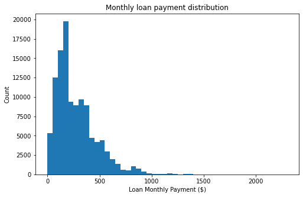

```python
#montly loan payment
df.MonthlyLoanPayment.value_counts()
binsize = 50
bins = np.arange(0, df['MonthlyLoanPayment'].max()+binsize, binsize)

plt.figure(figsize=[8, 5])
plt.hist(data = df, x = 'MonthlyLoanPayment', bins = bins)
plt.xlabel('Loan Monthly Payment ($)')
plt.ylabel('Count')
plt.title('Monthly loan payment distribution')
plt.show()
```

There is a long tail in the distribution, so we will apply log scale.

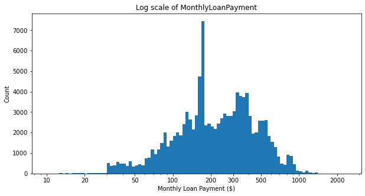

```python
log_binsize = 0.025
bins = 10 ** np.arange(1, np.log10(df['MonthlyLoanPayment'].max())+log_binsize, log_binsize)

plt.figure(figsize=[10, 5])
plt.hist(data = df, x = 'MonthlyLoanPayment', bins = bins)
plt.xscale('log')
plt.xticks([10, 20, 50, 100, 200,300, 500, 1e3, 2e3], ['10', '20','50', '100', '200', '300','500', '1000', '2000'])
plt.xlabel('Monthly Loan Payment ($)')

plt.ylabel('Count')
plt.title('Log scale of MonthlyLoanPayment')
plt.show()
```

There is a peak between 100 and 200 monthly payments.

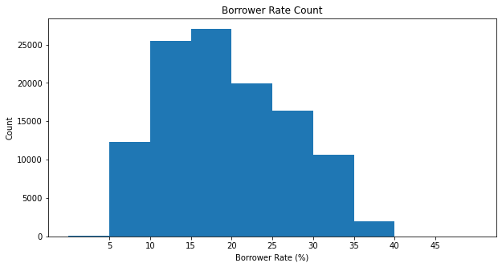

```python
#borrower rate
df.BorrowerRate.describe()
binsize = 5
borrower_perc = df['BorrowerRate']*100
bins = np.arange(0, df['BorrowerRate'].max()*100+binsize, binsize)

plt.figure(figsize=[10, 5])
plt.hist(x = borrower_perc, bins = bins)
plt.xlabel('Borrower Rate (%)')
plt.ylabel('Count')
plt.xticks([5,10, 15, 20, 25, 30, 35, 40, 45], ['5','10', '15', '20', '25', '30', '35', '40', '45'])
plt.title('Borrower Rate Count')
plt.show()
```

Majority of the borrower rate ranges between 15% and 20%

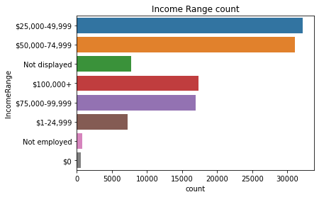

```python
#Income RAnge
df.IncomeRange.value_counts()

sb.countplot(data = df, y= 'IncomeRange')
plt.title('Income Range count')
```

Majority of the borrowers fall under $(25000-49999) income range.

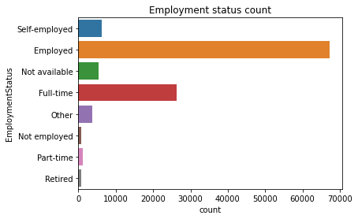

```python
#employment status

sb.countplot(data = df, y= 'EmploymentStatus')
plt.title('Employment status count')
```

Majority of the borrowers in the dataset are employed.

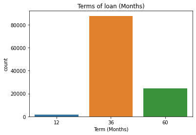

```python
#Term
sb.countplot(data=df,x= 'Term');
plt.title('Terms of loan (Months)')
plt.xlabel('Term (Months)');
```

Majority of the loan has a term of 36 months(3 years)

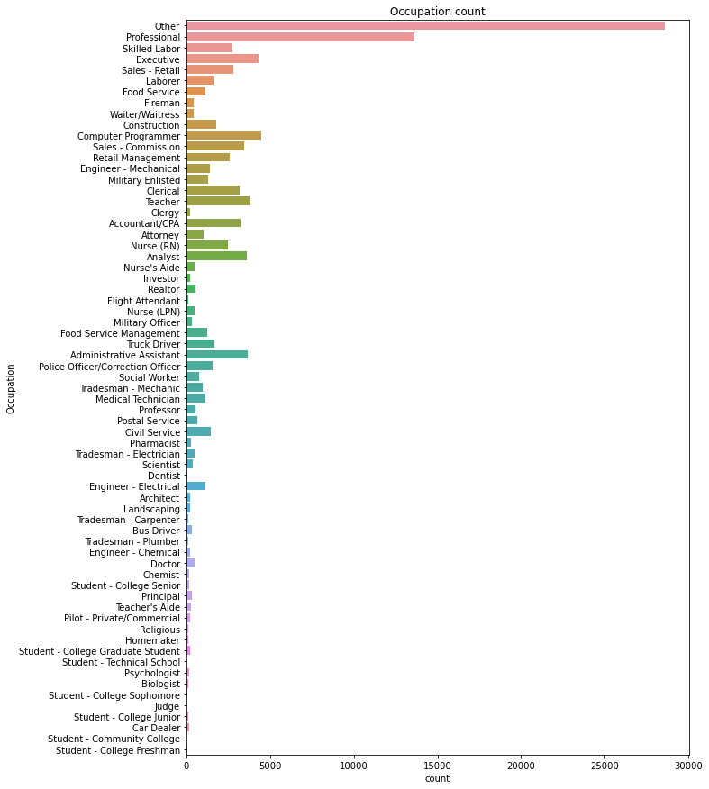

```python
plt.figure(figsize = [10, 15])
sb.countplot(data = df, y= 'Occupation')
plt.title('Occupation count')
```

### Of the features you investigated, were there any unusual distributions? Did you perform any operations on the data to tidy, adjust, or change the form of the data? If so, why did you do this?

> Some features such as MonthlyLoanPayment and LoanOriginal Amounthad long-tailed, skewed distributions, these were checked on a log-scale which revealed the hidden distribution in some areas.

## Bivariate Exploration

> In this section, investigate relationships between pairs of variables in your data. Make sure the variables that you cover here have been introduced in some fashion in the previous section (univariate exploration).

```python
## categorizing the data
numerical_variables = ['LoanOriginalAmount', 'BorrowerRate', 'MonthlyLoanPayment','ProsperScore']
categorical_variables = ['Term', 'EmploymentStatus','Occupation','LoanStatus','IncomeRange']
```

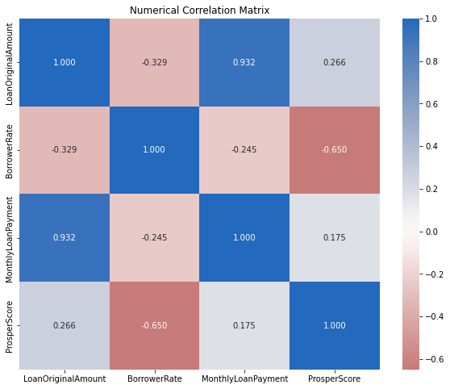

```python
# Correlation matrix for numerical variables
plt.figure(figsize = [10, 8])
sb.heatmap(df[numerical_variables].corr(), annot = True, fmt = '.3f',
           cmap = 'vlag_r', center = 0)
plt.title('Numerical Correlation Matrix')
plt.margins(x = 0.5, y= 0.3)
plt.show()
```

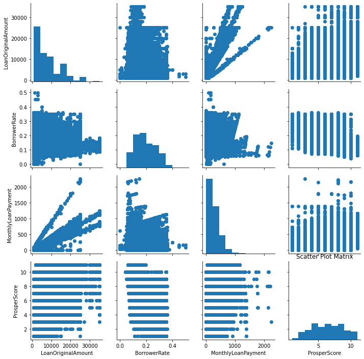

```python
# Building a grid of scatter plots
g = sb.PairGrid(data = df, vars = numerical_variables)
g.map_offdiag(plt.scatter)
g = g.map_diag(plt.hist, bins = 10)
plt.title('Scatter Plot Matrix');
```

There is:

- a strong positive correlation between loan original amount and monthly loan payment,
- ProsperScore vs BorrowerRate have a negative correlation
- MonthlyLoan Payment vs BorrowerRate have a negative relationship
- LoanOriginalAmount vs BorrowerRate have a negative relaionship

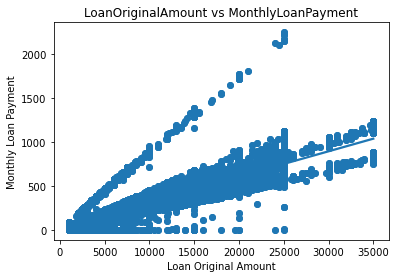

```python
# Scatter plot of LoanOriginalAmount and MonthlyLoanPayment
plt.scatter(data = df, x = 'LoanOriginalAmount', y = 'MonthlyLoanPayment');
plt.xlabel('Loan Original Amount')
plt.ylabel('Monthly Loan Payment')

sb.regplot(data = df, x = 'LoanOriginalAmount', y = 'MonthlyLoanPayment');
plt.xlabel('Loan Original Amount')
plt.ylabel('Monthly Loan Payment')
plt.title('LoanOriginalAmount vs MonthlyLoanPayment')
```

- LoanOriginalAmount and Monthly Loan Payment have a positive correlation. The more the LoanOriginalAmount the more the MonthlyLoanPayment.

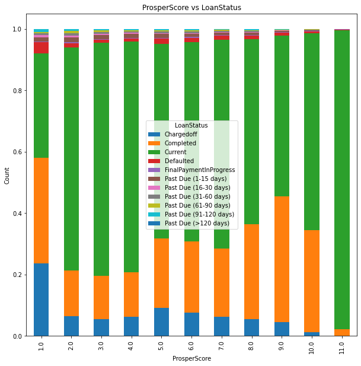

```python
#prosperscore vs loanstatus
occup= pd.crosstab(df['ProsperScore'], df['LoanStatus'])
occup.div(occup.sum(1).astype(float),axis=0).plot(kind='bar',stacked=True,figsize=(10,10))
plt.title('ProsperScore vs LoanStatus');
plt.ylabel('Count')
plt.show()
```

- Borrowers with Prosperscore of 1 have the highest Chargedoff loans
- Borrowers with ProsperScore of 9 and 1 have the highest Completed loans
- Borrowers with ProsperScore of 11 have majority of their loans being Current
- Borrowers with ProsperScore 1 have the highest number of defaulted loans

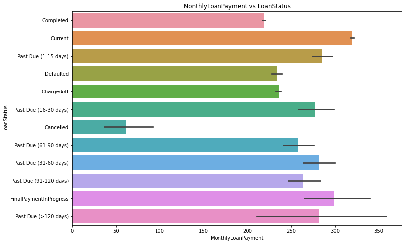

```python
# monthlyloanpaymentvs loan status
plt.figure(figsize = [12, 8])
sb.barplot(y='LoanStatus',x='MonthlyLoanPayment',data=df);

plt.title('MonthlyLoanPayment vs LoanStatus');
```

Monthly loan payments are the highest under current loans.

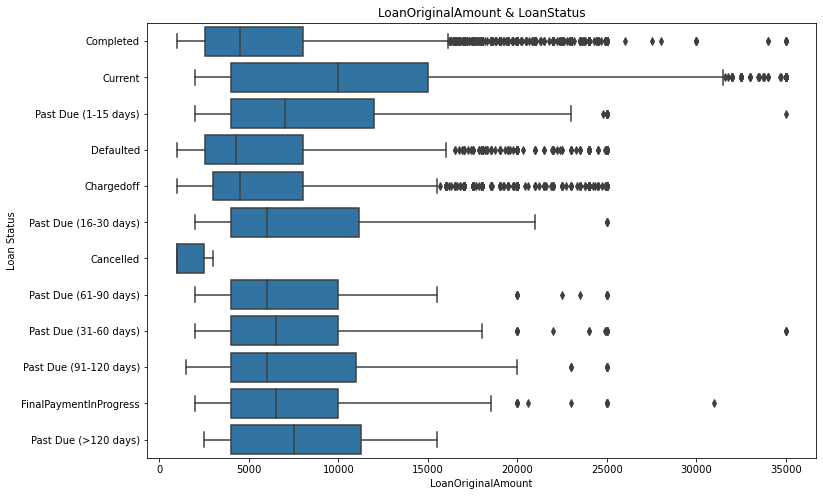

```python
plt.figure(figsize = [12, 8])
sb.boxplot(data=df, x='LoanOriginalAmount',y='LoanStatus',color=base_color);
plt.xlabel('LoanOriginalAmount');
plt.ylabel('Loan Status');
plt.title('LoanOriginalAmount & LoanStatus');
```

- Current loans have a higher LoanOriginalAmount than completed loans

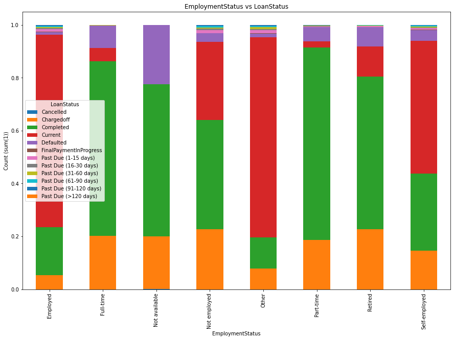

```python
#employmentstatus vs loan status
employ= pd.crosstab(df['EmploymentStatus'], df['LoanStatus'])
employ.div(employ.sum(1).astype(float),axis=0).plot(kind='bar',stacked=True,figsize=(15,10))
plt.ylabel('Count (sum(1))');
plt.title('EmploymentStatus vs LoanStatus');
plt.show()
```

- Majority of Employed borrowers have current loans.
- Majority of Full time employees have Completed loans.
- The highest completed loans come from full time and part time borrowers.
- Employed and other then self employed have current loans.
- Not Available(Employment status not stated ) have the highest defaulting rate followed by full time and retired.

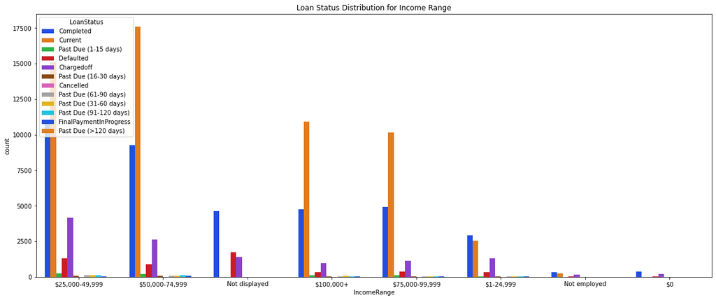

```python
plt.figure(figsize = [20, 8])


sb.countplot(data = df, x = 'IncomeRange', hue = 'LoanStatus', palette='bright')
plt.title('Loan Status Distribution for Income Range');
```

- Income Range 50k-74999 has the highest current loans
- 25k-49999 has the highest completed as well as the highest charged off.
- Income Not displayed has the highest defaulted loan.
- Majority of borrowers fall under the $(25000-49999) income range

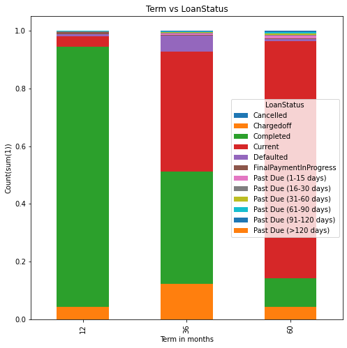

```python
#term vs loan status
term= pd.crosstab(df['Term'], df['LoanStatus'])
term.div(term.sum(1).astype(float),axis=0).plot(kind='bar',stacked=True,figsize=(8,8))
plt.title('Term vs LoanStatus');
plt.xlabel('Term in months')
plt.ylabel('Count(sum(1))')
plt.show()
```

- Loans whose term is 1 year have a higher completed status.
- Loans whose term is 5 years have a higher current status.
- The shorter the term of the loan the higher the chances of being completed.

### Talk about some of the relationships you observed in this part of the investigation. How did the feature(s) of interest vary with other features in the dataset?

> There is:
> - a strong positive correlation between loan original amount and monthly loan payment,
> - ProsperScore vs BorrowerRate have a negative correlation
> - MonthlyLoan Payment vs BorrowerRate have a negative relationship
> - LoanOriginalAmount vs BorrowerRate have a negative relaionship
> - LoanOriginalAmount and Monthly Loan Payment have a positive correlation. The more the LoanOriginalAmount the more the MonthlyLoanPayment.
> - Borrowers with Prosperscore of 1 have the highest Chargedoff loans
> - Borrowers with ProsperScore of 9 and 1 have the highest Completed loans
> - Borrowers with ProsperScore of 11 have majority of their loans being Current
> - Borrowers with ProsperScore 1 have the highest number of defaulted loans
> - Majority of Employed borrowers have current loans.
> - Majority of Full time employees have Completed loans.
> - The highest completed loans come from full time and part time borrowers.
> - Employed and other then self employed have current loans.
> - Not Available(Employment status not stated ) have the highest defaulting rate followed by full time and retired.
> - Income Range 50k-74999 has the highest current loans
> - 25k-49999 has the highest completed as well as the highest charged off.
> - Income Not displayed has the highest defaulted loan.
> - Majority of borrowers fall under the $(25000-49999) income range
> - Loans whose term is 1 year have a higher completed status.
> - Loans whose term is 5 years have a higher current status.
> - The shorter the term of the loan the higher the chances of being completed.

### Did you observe any interesting relationships between the other features (not the main feature(s) of interest)?

> - ProsperScore vs BorrowerRate have a negative correlation
>   - LoanOriginalAmount vs BorrowerRate have a negative relaionship
>   - MonthlyLoan Payment vs BorrowerRate have a negative relationship

## Multivariate Exploration

> Create plots of three or more variables to investigate your data even further. Make sure that your investigations are justified, and follow from your work in the previous sections.

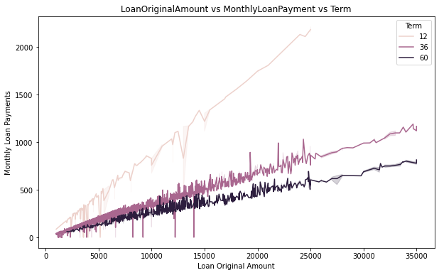

```python
#monthly loan payment vs loanOriginalAmount vs Term
plt.figure(figsize = [10, 6])
sb.lineplot(data=df, x = 'LoanOriginalAmount', y='MonthlyLoanPayment', hue='Term')
plt.xlabel('Loan Original Amount')
plt.ylabel('Monthly Loan Payments')
plt.title('LoanOriginalAmount vs MonthlyLoanPayment vs Term');
```

- The lower the term, the higher the monthly loan payments, as seen with 12 months term having the highest monthly loan payments.
- The longer the term, the higher the loan original amount.

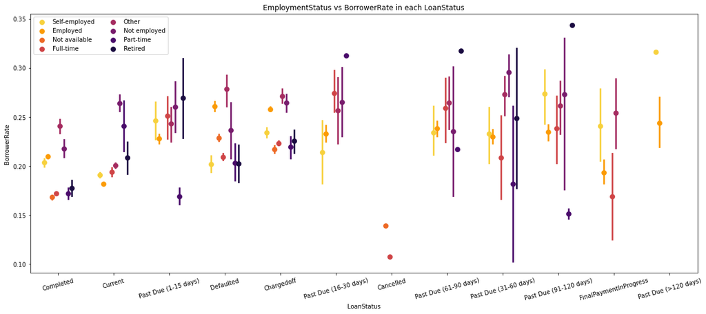

```python
# loan original amount, borrower rate vs loan status
fig = plt.figure(figsize = [20,8])
ax = sb.pointplot(data = df, x = 'LoanStatus', y = 'BorrowerRate', hue = 'EmploymentStatus', linestyles = "",
                  dodge = 0.5, palette = 'inferno_r')
plt.title('EmploymentStatus vs BorrowerRate in each LoanStatus')
plt.ylabel('BorrowerRate')
plt.xticks(rotation=15)
plt.legend(ncol=2)
plt.show();
```

Past Due loans generally have higher interest rates in all employment statuses

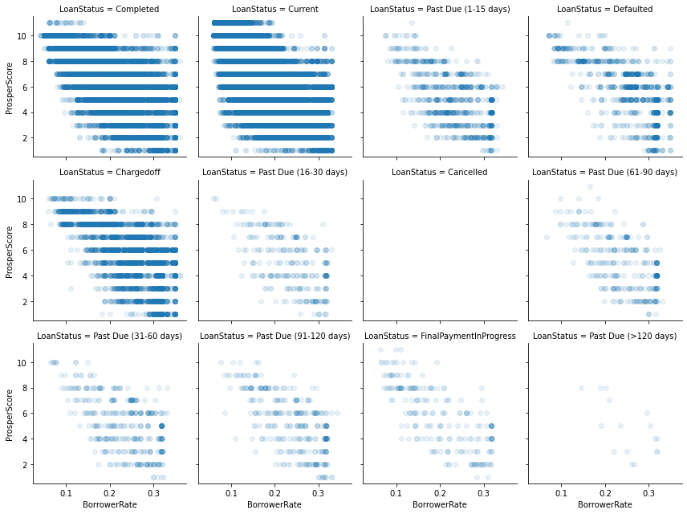

```python
g = sb.FacetGrid(data = df, col = 'LoanStatus', col_wrap = 4, height= 3)
g.map(plt.scatter, 'BorrowerRate', 'ProsperScore', alpha = 0.1)
g.set_xlabels('BorrowerRate')
g.set_ylabels('ProsperScore');
```

ProsperScore and BorrowerRate have a negative correlation. Borrower rate increases with decrease in ProsperScore. The higher the risk the higher the borrower rate. Majority of the borrowers fall under loan Status (completed, current and charged off). Most of higher prosperscore and lower borrower rate fall under current loan status.

### Talk about some of the relationships you observed in this part of the investigation. Were there features that strengthened each other in terms of looking at your feature(s) of interest?

> The lower the term, the higher the monthly loan payments, as seen with 12 months term having the highest monthly loan payments. The longer the term, the higher the loan original amount.

> ProsperScore and BorrowerRate have a negative correlation. Borrower rate increases with decrease in ProsperScore. The higher the risk the higher the borrower rate. Majority of the borrowers fall under loan Status (completed, current and charged off). Most of higher prosperscore and lower borrower rate fall under current loan status.

## Conclusions

> Past Due loans generally have higher interest rates in all employment statuses Term, ProsperScore, LoanOriginalAmount, MonthlyLoanPayment, BorrowerRate affect the status of the loan. They determine whether a loan is complete, current, past due, charged-off.